# Lab 6

Name:Liying Deng

```r
library(tidytext)
library(data.table)
library(ggplot2)
library(readr)
library(dplyr)
mt_samples <- read_csv("https://raw.githubusercontent.com/USCbiostats/data-science-data/master/00_mtsamples/mtsamples.csv")
mt_samples <- mt_samples %>%
  select(description, medical_specialty, transcription)
head(mt_samples)
```

```
# A tibble: 6 × 3
  description                                    medical_specialty transcription
  <chr>                                          <chr>             <chr>
1 A 23-year-old white female presents with comp… Allergy / Immuno… "SUBJECTIVE:…
2 Consult for laparoscopic gastric bypass.       Bariatrics        "PAST MEDICA…
3 Consult for laparoscopic gastric bypass.       Bariatrics        "HISTORY OF …
4 2-D M-Mode. Doppler.                           Cardiovascular /… "2-D M-MODE:…
5 2-D Echocardiogram                             Cardiovascular /… "1.  The lef…
6 Morbid obesity.  Laparoscopic antecolic anteg… Bariatrics        "PREOPERATIV…
```

```r
print(mt_samples)
```

```
# A tibble: 4,999 × 3
   description                                   medical_specialty transcription
   <chr>                                         <chr>             <chr>
 1 "A 23-year-old white female presents with co… Allergy / Immuno… "SUBJECTIVE:…
 2 "Consult for laparoscopic gastric bypass."    Bariatrics        "PAST MEDICA…
 3 "Consult for laparoscopic gastric bypass."    Bariatrics        "HISTORY OF …
 4 "2-D M-Mode. Doppler."                        Cardiovascular /… "2-D M-MODE:…
 5 "2-D Echocardiogram"                          Cardiovascular /… "1.  The lef…
 6 "Morbid obesity.  Laparoscopic antecolic ant… Bariatrics        "PREOPERATIV…
 7 "Liposuction of the supraumbilical abdomen, … Bariatrics        "PREOPERATIV…
 8 "2-D Echocardiogram"                          Cardiovascular /… "2-D ECHOCAR…
 9 "Suction-assisted lipectomy - lipodystrophy … Bariatrics        "PREOPERATIV…
10 "Echocardiogram and Doppler"                  Cardiovascular /… "DESCRIPTION…
# ℹ 4,989 more rows
```

#Question 1

```r
mt_samples %>%
  count(medical_specialty, sort = TRUE)
```

```
# A tibble: 40 × 2
   medical_specialty                 n
   <chr>                         <int>
 1 Surgery                        1103
 2 Consult - History and Phy.      516
 3 Cardiovascular / Pulmonary      372
 4 Orthopedic                      355
 5 Radiology                       273
 6 General Medicine                259
 7 Gastroenterology                230
 8 Neurology                       223
 9 SOAP / Chart / Progress Notes   166
10 Obstetrics / Gynecology         160
# ℹ 30 more rows
```

#Question 2

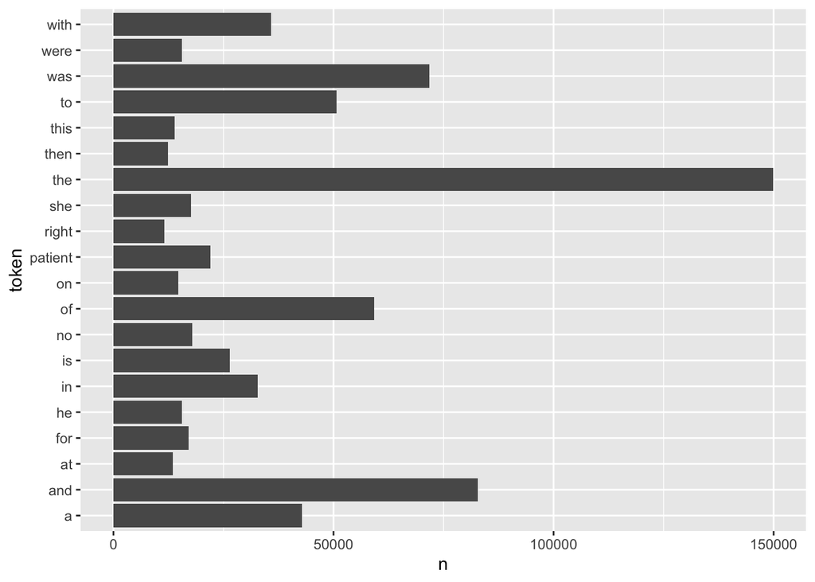

```r
library(dplyr)
library(ggplot2)
mt_samples |>
  unnest_tokens(token, transcription) |>
  count(token) |>
  top_n(20, n) |>
  ggplot(aes(n, token)) +
  geom_col()
```

#Conclusion : Yes, the result makes sense. This bar chart visualizes the top 20 most frequent words in a collection of transcriptions from medical records.The word “patient” appears with relatively high frequency, which makes sense in the context of medical transcriptions, where much of the content likely refers to patient care or patient conditions. we can easier to explore the frequency of medical terms or diagnostic words to gain insights into common conditions, treatments, or patient details being recorded in the transcriptions.

#Question 3

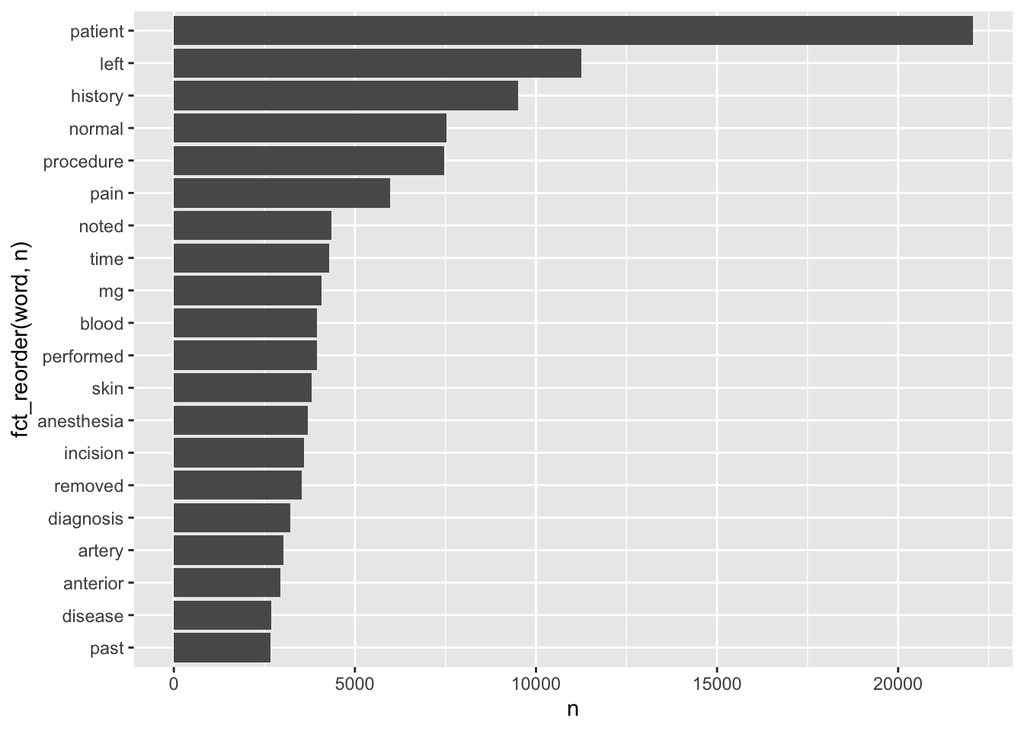

```r
library(stringr)
data("stop_words")
library("forcats")
mt_samples |>
  unnest_tokens(word, transcription) |>
  anti_join(stop_words, by = c("word")) |>
  filter(!str_detect(word, "^[0-9]+$")) |>
  count(word, sort = TRUE) |>
  top_n(20, n) |>
  ggplot(aes(n, fct_reorder(word, n))) +
  geom_col()
```

#Conclusion: Words like “patient,” “procedure,” “pain,” “blood,” “diagnosis,” “anesthesia,” and “incision” are among the most frequent, indicating that the transcriptions contain detailed medical information.This helps in understanding that the text focuses on medical procedures, patient care, and diagnoses, giving us a much clearer insight into the nature of the transcriptions.

#Question 4

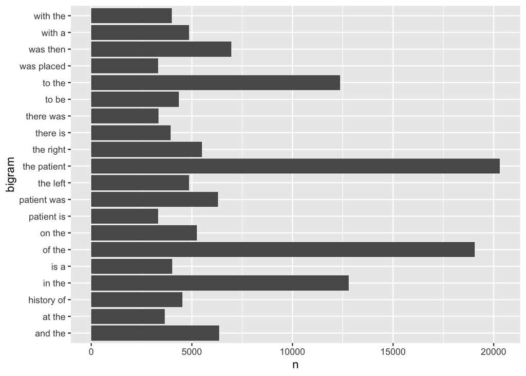

```r
#Bi-gram visualize
library(dplyr)
library(ggplot2)
library(tidytext)
mt_samples |>
  unnest_tokens(bigram, transcription, token = "ngrams", n = 2) |>
  count(bigram) |>
  top_n(20, n) |>
  ggplot(aes(n, bigram)) +
  geom_col()
```

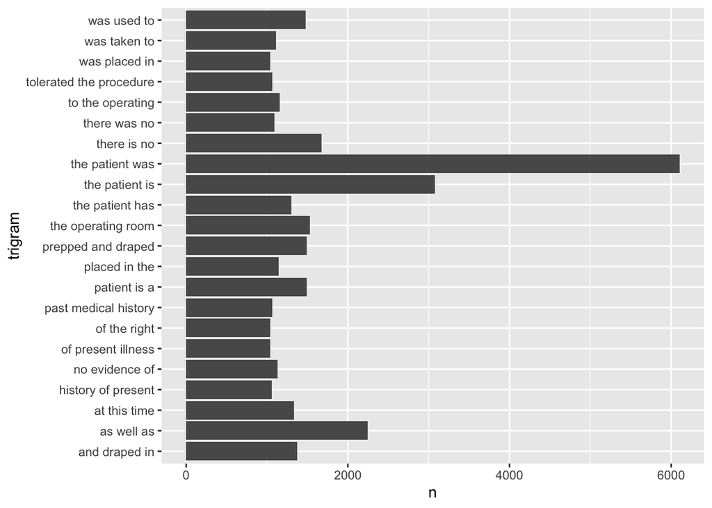

```r
#Tri-gram visualize
mt_samples |>
  unnest_tokens(trigram, transcription, token = "ngrams", n = 3) |>
  count(trigram) |>
  top_n(20, n) |>
  ggplot(aes(n, trigram)) +
  geom_col()
```

#Compare with Bi-grams, Tri-grams provide more complete phrases that reflect specific actions or medical evaluations (e.g., “past medical history” or “the paitent has”). This level of detail gives a clearer understanding of the medical narratives being recorded.

#Question 5

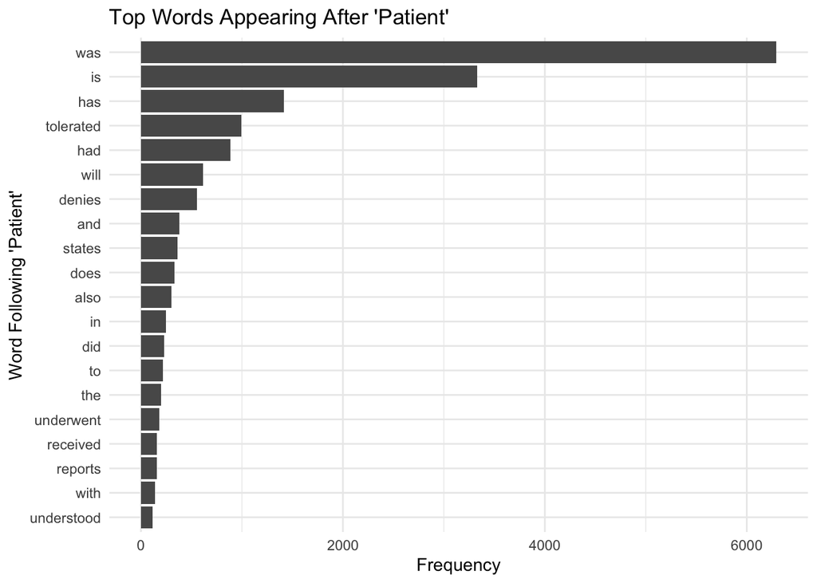

```r
library(dplyr)
library(tidytext)
library(ggplot2)
library(tidyr)
bi_grams <- mt_samples %>%
  unnest_tokens(bigram, transcription, token = "ngrams", n = 2) %>%
  separate(bigram, into = c("word1", "word2"), sep = " ")
after_patient <- bi_grams %>%
  filter(word1 == "patient") %>%
  count(word2, sort = TRUE) %>%
  head(20)
before_patient <- bi_grams %>%
  filter(word2 == "patient") %>%
  count(word1, sort = TRUE) %>%
  head(20)
ggplot(after_patient, aes(x = n, y = reorder(word2, n))) +
  geom_col() +
  labs(title = "Top Words Appearing After 'Patient'",
       x = "Frequency",
       y = "Word Following 'Patient'") +
  theme_minimal()
```

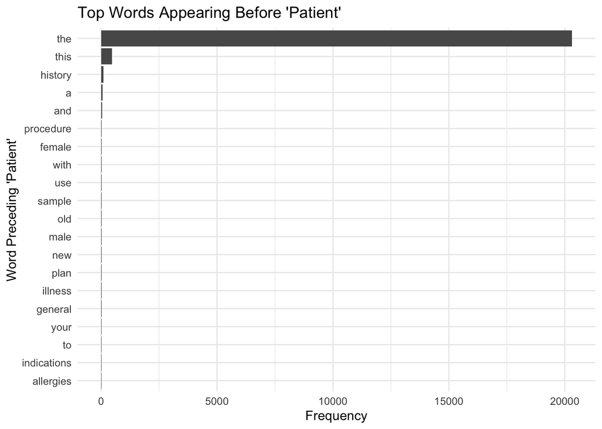

```r
ggplot(before_patient, aes(x = n, y = reorder(word1, n))) +
  geom_col() +
  labs(title = "Top Words Appearing Before 'Patient'",
       x = "Frequency",
       y = "Word Preceding 'Patient'") +
  theme_minimal()
```

#The most frequent words appearing directly after “patient” are “was,” “is,” and “has”. The most frequent word before “patient” is “the”.

#Question 6

```r
library(dplyr)
library(tidytext)
data("stop_words")
top_words_by_medical_specialty <- mt_samples %>%
  unnest_tokens(word, transcription) %>%
  anti_join(stop_words, by = "word") %>%
  filter(!str_detect(word, "^[0-9]+$")) %>%
  group_by(medical_specialty) %>%
  count(word, sort = TRUE) %>%
  top_n(5, n) %>%
  ungroup()
top_words_by_medical_specialty
```

```
# A tibble: 210 × 3
   medical_specialty          word           n
   <chr>                      <chr>      <int>
 1 Surgery                    patient     4855
 2 Surgery                    left        3263
 3 Surgery                    procedure   3243
 4 Consult - History and Phy. patient     3046
 5 Consult - History and Phy. history     2820
 6 Orthopedic                 patient     1711
 7 Surgery                    anesthesia  1687
 8 Surgery                    incision    1641
 9 Cardiovascular / Pulmonary left        1550
10 Cardiovascular / Pulmonary patient     1516
# ℹ 200 more rows
```

#We can see the top 5 words from the different medical specialty.